# Coursera Data Science Capstone: Milestone Report

Pathik Chamaria

May 13, 2017

## Synopsis

This is the Milestone Report for the Coursera Data Science Capstone project. The goal of the capstone project is to create a predictive text model using a large text corpus of documents as training data. Natural language processing techniques will be used to perform the analysis and build the predictive model.

This milestone report describes the major features of the training data with our exploratory data analysis and summarizes our plans for creating the predictive model.

## Getting the data

For the purpose of creating a predictive input model, we have been supplied with a dataset https://d396qusza40orc.cloudfront.net/dsscapstone/dataset/Coursera-SwiftKey.zip, containing twitter, news and blog data for 4 languages.

For this part we’ll be solely focussing on the English corpus.

```r
files <- dir("en_US/")
con <- file(paste("en_US/",files[1], sep = ""))
blog <- read_lines(con,-1)
con <- file(paste("en_US/",files[2], sep = ""))
news <- read_lines(con,-1)
con <- file(paste("en_US/",files[3], sep = ""))
twitter <- read_lines(con,-1)
```

## Summary

We examin the data sets and summarize our findings (file sizes, line counts, word counts) below.

```r
sum_table <- function(files){
    df <- data.frame(file = files)
    df$'size in mb' <-  round(file.size(paste("en_US/",files, sep = ""))/1024/1024,1)
    df$'no. of lines' <- c(length(blog),length(news),length(twitter))
    wordCount <- function(lns){
        sum(sapply(gregexpr("\\S+", lns), length))
    }
    df$'no. of words' <- c(wordCount(blog),wordCount(news),wordCount(twitter))
    df$'no. of char' <- c(sum(nchar(blog)),sum(nchar(news)),sum(nchar(twitter)))
    df
}

sum_table(files)
```

```
##                file size in mb no. of lines no. of words no. of char
## 1   en_US.blogs.txt      200.4       899288     37334131   206824505
## 2    en_US.news.txt      196.3      1010242     34372530   203223159
## 3 en_US.twitter.txt      159.4      2360148     30373543   162096031
```

As we can see all datasets differ in amount of lines, but in total each has roughly between 30-37M words.

## Sampling

Since the English language has between 2k and 5k most common used words (depending on which source you lookup), we probably won’t need all 100M words to be analyzed.

There are ways to calculate the needed sample size, but they don’t reaaly seem to apply to this problem, however.

If we just take 10% of all datasets we still end up with 10M words to be analyzed.

```r
set.seed(123)

blog <- blog[sample(1:length(blog), length(blog)*0.1)]
news <- news[sample(1:length(news), length(news)*0.1)]
twitter <- twitter[sample(1:length(twitter), length(twitter)*0.1)]

data <- c(blog,news,twitter)
```

## Cleaning The Data

Before going ahead, we must clean the data first. This involves removing URLs and UTF chars. Also the text converted to lower case.

```r
clean_data <- gsub("(f|ht)tp(s?)://(.*)[.][a-z]+", " ",data)

clean_data <- enc2native(clean_data)

clean_data <- tolower(clean_data)

clean_data <- gsub("(<u[\\+].{4}>)", " ", clean_data)
```

## Tokenization

To actually parse the word’s we are going to use a **whitespace tokenizer**. First we’ll split each line into sentences, because the end of a sentence should probably not be a predictor for the next one. This way we’ll keep tokization independant of context. Then we’ll remove all non word chars and split on whitespace. We also expand some of the most common abbreavations in the data.

```r
sent <- strsplit(clean_data, "[\\.\\,!\\?\\:]+")

sent <- unlist(sent)

clean_sent <- gsub("[[:space:]]+", " ", trimws(gsub("[^[:lower:]]", " ",sent)))

clean_sent <- gsub("don t", "do not", clean_sent)
clean_sent <- gsub("it s", "it is", clean_sent)
clean_sent <- gsub("i m", "i am", clean_sent)
clean_sent <- gsub("can t", "can not", clean_sent)
clean_sent <- gsub("didn t", "did not", clean_sent)
clean_sent <- gsub("i ve", "i have", clean_sent)
clean_sent <- gsub("you re", "you are", clean_sent)
clean_sent <- gsub("that s", "that is", clean_sent)
clean_sent <- gsub("he s", "he is", clean_sent)
clean_sent <- gsub("i ll", "i will", clean_sent)
clean_sent <- gsub("doesn t", "does not", clean_sent)
clean_sent <- gsub("wouldn t", "would not", clean_sent)
clean_sent <- gsub("we re", "we are", clean_sent)
clean_sent <- gsub("there s", "there is", clean_sent)
clean_sent <- gsub("isn t", "is not", clean_sent)
clean_sent <- gsub("i d", "i would", clean_sent)
clean_sent <- gsub("world s", "world is", clean_sent)
clean_sent <- gsub("company s", "company is", clean_sent)
clean_sent <- gsub("what s", "what is", clean_sent)
clean_sent <- gsub("haven t", "have not", clean_sent)
```

Next, we will remove some the sentences which are blank. We also perform the tokenization to have a list of term vectors

```r
blank <- clean_sent == ""

clean_sent <- clean_sent[!blank]

sent_words <- strsplit(clean_sent, " ")
```

## Explore

### 1. View data

Now we have a sample tokenize dataset. Let’s explore

```r
head(sent_words, 3)
```

```
## [[1]]
## [1] "to"   "sum"  "this" "up"
##
## [[2]]
## [1] "when"     "we"       "are"      "unjustly" "wounded"  "by"
## [7] "men"
##
## [[3]]
##  [1] "let"        "us"         "overlook"   "their"      "wickedness"
##  [6] "which"      "would"      "but"        "worsen"     "our"
## [11] "pain"       "and"        "sharpen"    "our"        "minds"
## [16] "to"         "revenge"
```

```r
#Num lines
length(sent_words)
```

```
## [1] 1360762
```

```r
#Num terms
sum(sapply(sent_words, length))
```

```
## [1] 10307494
```

We ended up with almost 10M terms divided over >1.3M sentences (term vectors)

### 2. Term frequencies

we can see what are the most common words in our dataset.

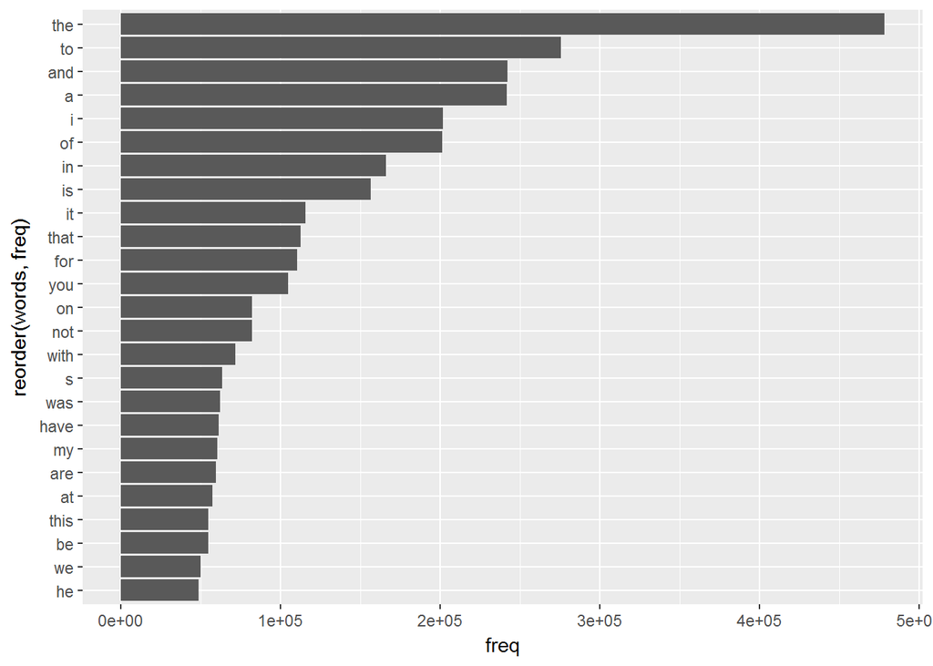

```r
words <- unlist(sent_words)
tab <- table(words)
tab <- as.data.frame(tab)
plot(tab,25)
```

### 3. Create n-grams

Now we have term vectors, we can now create n-grams

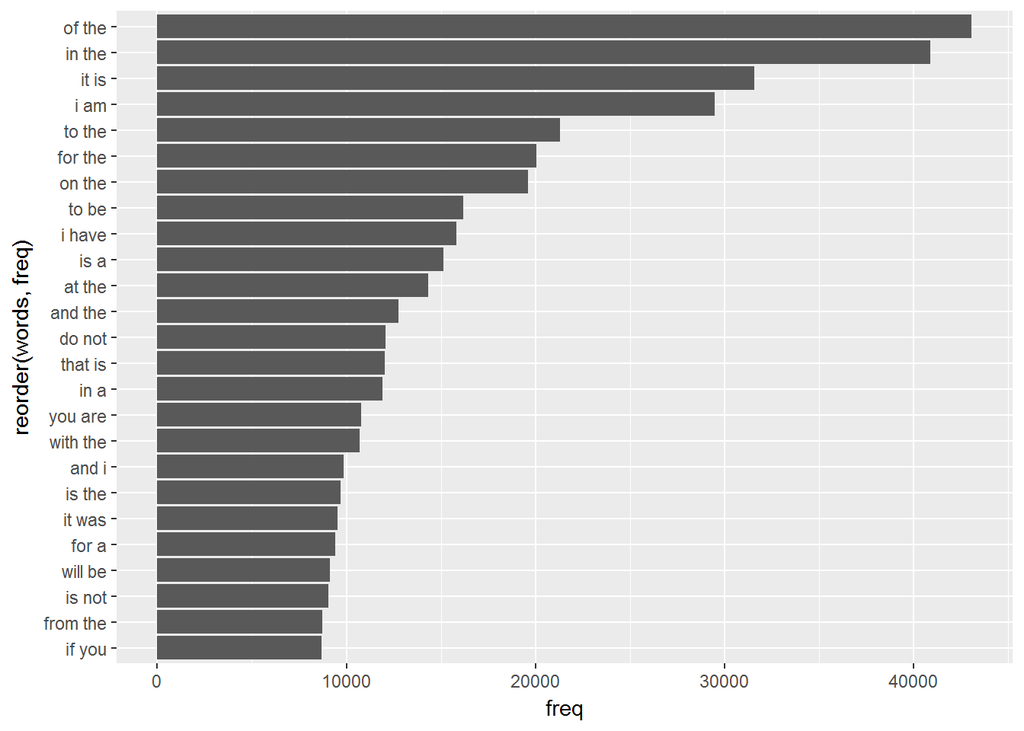

```r
bigram <- tokenize_ngrams(clean_sent, n = 2)
bigram_tokens <- unlist(bigram)
tab2 <- as.data.frame(table(bigram_tokens))
plot(tab2,25)
```

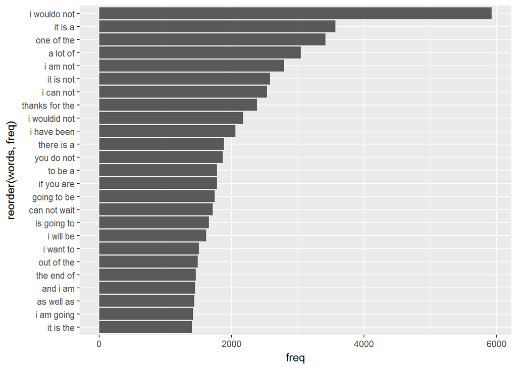

```r
trigram <- tokenize_ngrams(clean_sent, n = 3)
trigram_tokens <- unlist(trigram)
tab3 <- as.data.frame(table(trigram_tokens))
plot(tab3,25)
```

# Next Step

## 1. Prediction

We see that small parts of the data are responsible for the bulk of the corpus. This allows prediction to be a smaller model to just focus on the most important parts.

## 2. Next steps

- Reevaluate approach and see if sample size adjust,inclusion of stopwords, punctuation, numbers, etc improve prediction
- Building a predictive model using the identified tokens
- Wrapping up the results and the developed model as a data product, shiny app.